**Snow Ratios**

The **snow ratio** was a great tool in helping me estimate **snow depth**. As I explained in the index page, since we know the **SWE**, we can predict the **snow depth**, as long as we know the ratio between the two. This was the basis for estimating **snow depth**.  
Here are some questions I had when thinking about **snow ratios.**

- When does the snow ratio change?
- Is it affected by temperature?
- Is it affected by month?
- Is it affected by elevation?

I made a few visualizations in helping me answer those questions.

Elevation

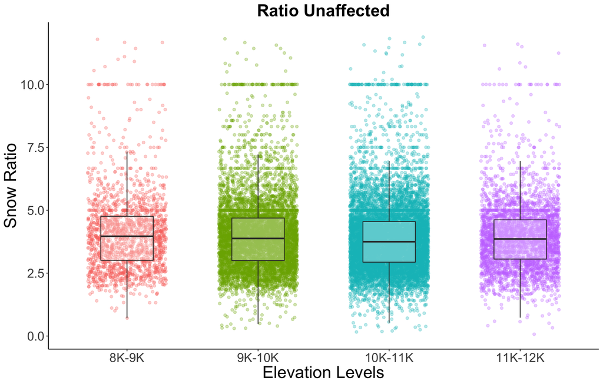

Holding other variables constant, elevation does not affect a visible change. However, what we do see that is interesting are the dense bands of observations with a 10:1 ratio, along with 7.5 , 7, and 5. These are furthur explained [here](https://byuidatascience.github.io/WolfeA_SeniorProject/odd_ratios.html).

Month

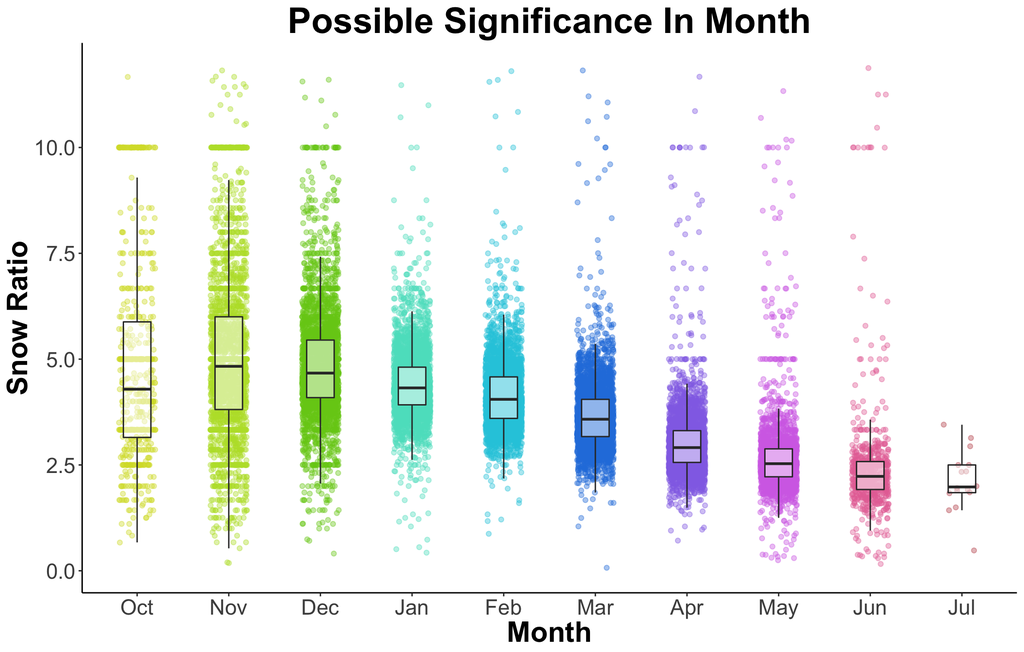

Unlike the *elevation graph*, there is both variation in spread and boxplot location with month, where the **snow ratio** seems to be highest and most spread in the fall.  
How will this help us?  
We always have the **SWE**, but not always the **snow depth**. Using the graph above, we know the ratio between the two, and we also know the ratio changes depending on the month. To find the **snow depth**, we simply multiply the ratios above by the **SWE**. Of course, the boxplots don’t give us super succinct values within the month, and that’s why later I performed a **regression.**

Temperature

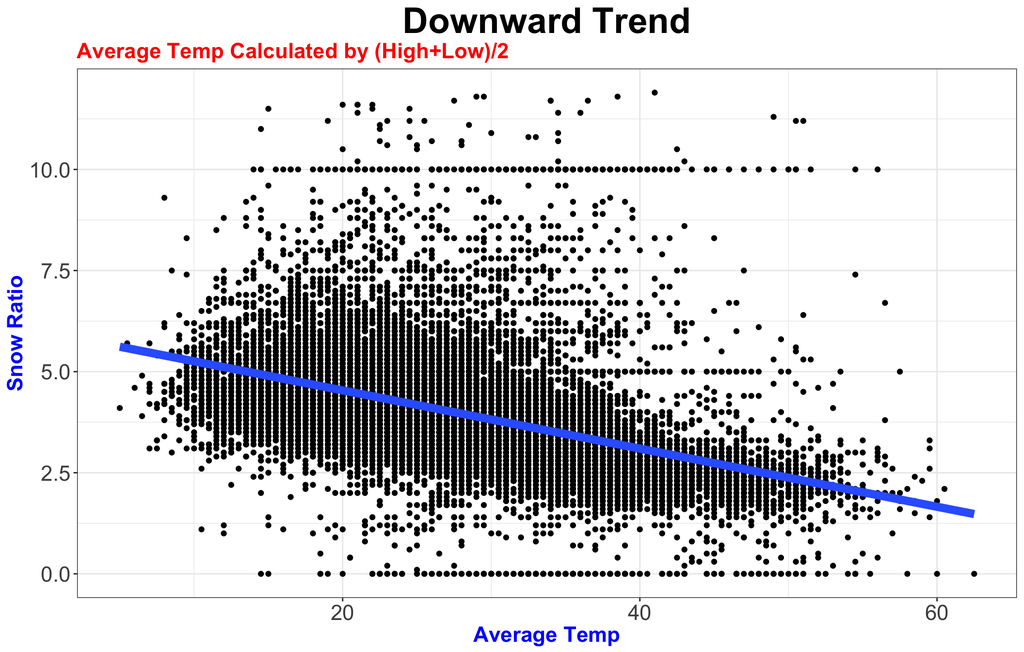

Temperature looks to also add some insight on how **snow ratio** changes, and probably is the driving reason behind why the ratio changes per **month**.  
Repeating observations at certain **snow ratios** are also easily seen.  
The regression I selected to use later involved both **month** and **temperature.**